# DS 1000 — Relationships in Practice

NBA Scoring Case | Instructor Analysis

DS 1000

# Purpose

This instructor-facing analysis builds the evidence for the September 23 **Relationships in Practice** session. The goal is to test the empirical story before turning it into slides.

The central claim is:

> **Players who attempt more three-pointers score more points because three-point shooting makes them more effective scorers.**

We will examine:

1. the raw relationship between three-point attempts (`fg3a`) and points (`pts`);
2. whether minutes played (`minutes`) is related to both variables;
3. whether the `fg3a`-`pts` relationship changes when we compare players with similar playing time.

The code below intentionally separates the descriptive evidence from the interpretation. The classroom activity should reveal the evidence in stages rather than show the entire analysis at once.

# 1. Load the NBA data

```r
knitr::opts_chunk$set(echo = TRUE, message = FALSE, warning = FALSE)

library(tidyverse)

nba <- readr::read_rds(
  "https://github.com/jbisbee1/DS1000_F2024/raw/main/data/nba_players_2018.Rds"
)
```

Check the variables we need.

```r
requested_vars <- c("player", "team", "pts", "fg3a", "minutes")

requested_vars[requested_vars %in% names(nba)]
```

```
## [1] "pts"     "fg3a"    "minutes"
```

A quick summary of the key variables:

```r
nba %>%
  summarise(
    n = n(),
    pts_missing = sum(is.na(pts)),
    fg3a_missing = sum(is.na(fg3a)),
    minutes_missing = sum(is.na(minutes)),
    pts_mean = mean(pts, na.rm = TRUE),
    fg3a_mean = mean(fg3a, na.rm = TRUE),
    minutes_mean = mean(minutes, na.rm = TRUE)
  )
```

| n | pts_missing | fg3a_missing | minutes_missing | pts_mean | fg3a_mean | minutes_mean |
| --- | --- | --- | --- | --- | --- | --- |
| 530 | 0 | 0 | 0 | 516.1755 | 148.5698 | 1121.632 |

# 2. Prepare an analysis dataset

For these plots, restrict to observations with the three variables required for the relevant comparison.

```r
nba_analysis <- nba %>%
  select(any_of(c("player", "team", "pts", "fg3a", "minutes"))) %>%
  filter(
    !is.na(pts),
    !is.na(fg3a),
    !is.na(minutes)
  )

nrow(nba_analysis)
```

```
## [1] 530
```

We will also keep an explicit record of the analysis choices for later teaching discussion.

```r
tibble(
  variable = c("fg3a", "pts", "minutes"),
  role = c("X: three-point attempts", "Y: points scored", "Z: minutes played"),
  interpretation = c(
    "Opportunity to take three-point shots",
    "Points scored during the season",
    "Opportunity to play and score"
  )
)
```

| variable | role | interpretation |
| --- | --- | --- |
| fg3a | X: three-point attempts | Opportunity to take three-point shots |
| pts | Y: points scored | Points scored during the season |
| minutes | Z: minutes played | Opportunity to play and score |

# 3. Evidence A — Three-point attempts and points

The first exhibit should establish the raw relationship without introducing minutes played.

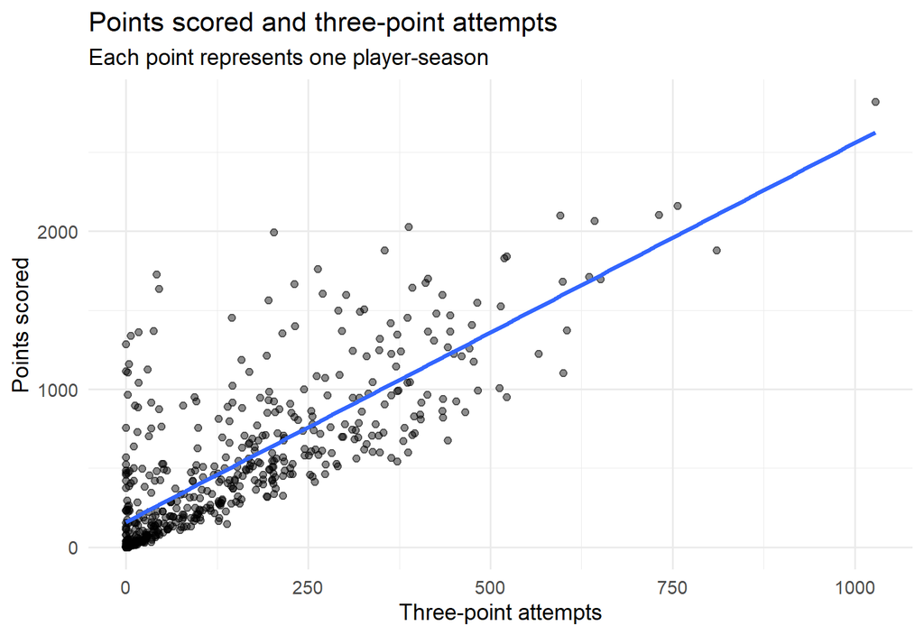

```r
ggplot(nba_analysis, aes(x = fg3a, y = pts)) +
  geom_point(alpha = 0.45) +
  geom_smooth(method = "lm", se = FALSE) +
  labs(
    title = "Points scored and three-point attempts",
    x = "Three-point attempts",
    y = "Points scored",
    subtitle = "Each point represents one player-season"
  ) +
  theme_minimal(base_size = 14)
```

A simple numerical summary helps us characterize the association without putting the statistic on the student-facing slide.

```r
nba_analysis %>%
  summarise(
    correlation = cor(fg3a, pts),
    fg3a_range_min = min(fg3a),
    fg3a_range_max = max(fg3a),
    pts_range_min = min(pts),
    pts_range_max = max(pts)
  )
```

| correlation | fg3a_range_min | fg3a_range_max | pts_range_min | pts_range_max |
| --- | --- | --- | --- | --- |
| 0.7808736 | 0 | 1028 | 0 | 2818 |

We can also inspect the fitted slope.

```r
summary(lm(pts ~ fg3a, data = nba_analysis))$coefficients
```

```
##               Estimate  Std. Error   t value      Pr(>|t|)
## (Intercept) 159.697483 18.20604867  8.771672  2.430108e-17
## fg3a          2.399397  0.08353499 28.723260 5.726302e-110
```

## Teaching interpretation

The important classroom questions are:

- Is the relationship positive or negative?
- Is it roughly linear?
- How much variation remains around the overall pattern?
- Does this graph establish that attempting more threes *causes* players to score more points?

The answer to the final question should be no: this exhibit is observational and does not by itself rule out common causes, selection, or reverse-direction stories.

# 4. Evidence B — Is minutes played a plausible third variable?

We now test the candidate confounder suggested in the worksheet: minutes played.

## B1. Minutes played and three-point attempts

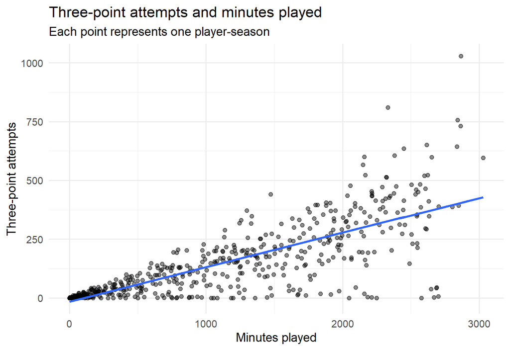

```r
ggplot(nba_analysis, aes(x = minutes, y = fg3a)) +
  geom_point(alpha = 0.45) +
  geom_smooth(method = "lm", se = FALSE) +
  labs(
    title = "Three-point attempts and minutes played",
    x = "Minutes played",
    y = "Three-point attempts",
    subtitle = "Each point represents one player-season"
  ) +
  theme_minimal(base_size = 14)
```

```r
nba_analysis %>%
  summarise(
    correlation_minutes_fg3a = cor(minutes, fg3a),
    slope_minutes_fg3a = coef(lm(fg3a ~ minutes, data = nba_analysis))["minutes"]
  )
```

| correlation_minutes_fg3a | slope_minutes_fg3a |
| --- | --- |
| 0.7712496 | 0.146779 |

## B2. Minutes played and points

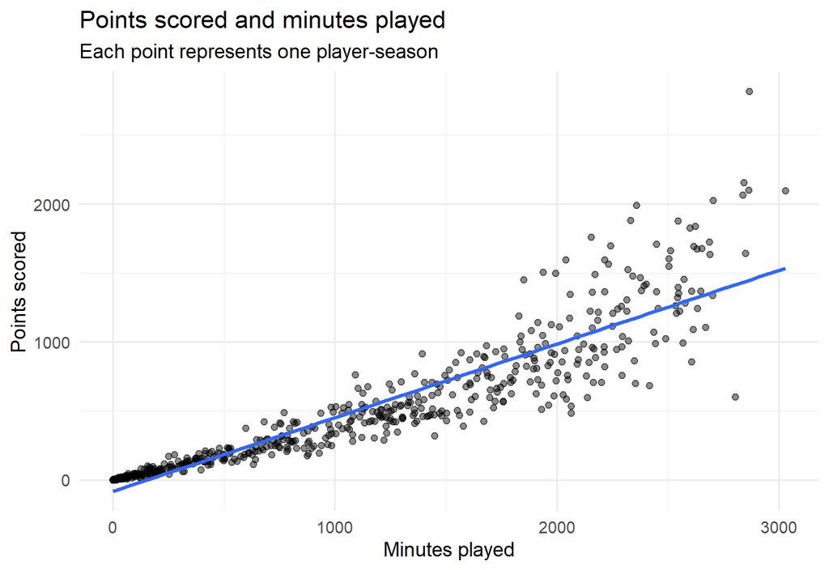

```r
ggplot(nba_analysis, aes(x = minutes, y = pts)) +
  geom_point(alpha = 0.45) +
  geom_smooth(method = "lm", se = FALSE) +
  labs(
    title = "Points scored and minutes played",
    x = "Minutes played",
    y = "Points scored",
    subtitle = "Each point represents one player-season"
  ) +
  theme_minimal(base_size = 14)
```

```r
nba_analysis %>%
  summarise(
    correlation_minutes_pts = cor(minutes, pts),
    slope_minutes_pts = coef(lm(pts ~ minutes, data = nba_analysis))["minutes"]
  )
```

| correlation_minutes_pts | slope_minutes_pts |
| --- | --- |
| 0.9144737 | 0.5347632 |

## Teaching interpretation

Minutes played is a plausible third variable if it is associated with both:

- the amount of opportunity a player has to attempt three-pointers; and
- the amount of opportunity a player has to score points.

The classroom task is not to declare minutes played a proven confounder. It is to recognize that the original X-Y comparison may mix together players with very different amounts of playing opportunity.

# 5. Evidence C — Compare like with like

The simplest student-facing conditional comparison is to divide minutes played into a small number of substantively interpretable groups and compare the relationship within each group.

For the classroom exhibit, use quartiles so that the groups contain roughly similar numbers of observations.

```r
nba_conditional <- nba_analysis %>%
  mutate(
    minutes_group = ntile(minutes, 4),
    minutes_group = factor(
      minutes_group,
      levels = 1:4,
      labels = c("Lowest minutes", "Low-mid minutes", "High-mid minutes", "Highest minutes")
    )
  )

nba_conditional %>%
  count(minutes_group)
```

| minutes_group | n |
| --- | --- |
| Lowest minutes | 133 |
| Low-mid minutes | 133 |
| High-mid minutes | 132 |
| Highest minutes | 132 |

Now plot the original relationship within minutes-played groups.

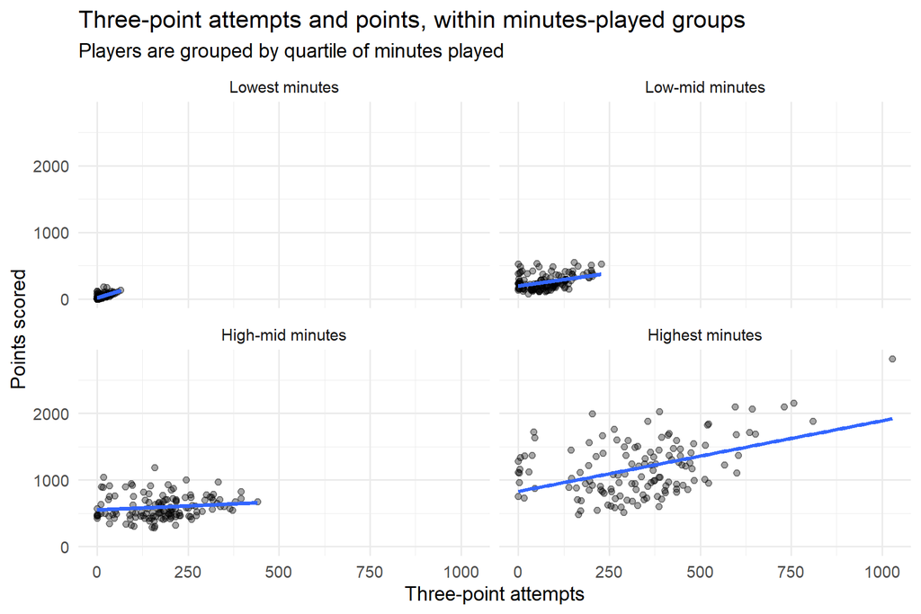

```r
ggplot(nba_conditional, aes(x = fg3a, y = pts)) +
  geom_point(alpha = 0.35) +
  geom_smooth(method = "lm", se = FALSE) +
  facet_wrap(~ minutes_group) +
  labs(
    title = "Three-point attempts and points, within minutes-played groups",
    x = "Three-point attempts",
    y = "Points scored",
    subtitle = "Players are grouped by quartile of minutes played"
  ) +
  theme_minimal(base_size = 14)
```

For a numerical check, estimate a separate slope within each group.

```r
conditional_slopes <- nba_conditional %>%
  group_by(minutes_group) %>%
  summarise(
    n = n(),
    correlation = cor(fg3a, pts),
    slope = coef(lm(pts ~ fg3a))["fg3a"],
    .groups = "drop"
  )

conditional_slopes
```

| minutes_group | n | correlation | slope |
| --- | --- | --- | --- |
| Lowest minutes | 133 | 0.6479895 | 1.7053304 |
| Low-mid minutes | 133 | 0.3943633 | 0.7708954 |
| High-mid minutes | 132 | 0.1379946 | 0.2424831 |
| Highest minutes | 132 | 0.4487345 | 1.0613926 |

A second way to summarize the conditional pattern is to compare the fitted slopes to the pooled relationship.

```r
pooled_slope <- coef(lm(pts ~ fg3a, data = nba_analysis))["fg3a"]

list(
  pooled_slope = pooled_slope,
  conditional_slopes = conditional_slopes
)
```

```
## $pooled_slope
##     fg3a
## 2.399397
##
## $conditional_slopes
## # A tibble: 4 × 4
##   minutes_group        n correlation slope
##   <fct>            <int>       <dbl> <dbl>
## 1 Lowest minutes     133       0.648 1.71
## 2 Low-mid minutes    133       0.394 0.771
## 3 High-mid minutes   132       0.138 0.242
## 4 Highest minutes    132       0.449 1.06
```

# 6. Optional robustness check — continuous adjustment

The classroom does not need this regression, but it is useful for the instructor to see whether the conditional story is broadly consistent with a simple linear adjustment for minutes.

```r
adjusted_model <- lm(pts ~ fg3a + minutes, data = nba_analysis)

summary(adjusted_model)$coefficients
```

```
##                Estimate  Std. Error   t value      Pr(>|t|)
## (Intercept) -74.4249361 13.85740786 -5.370769  1.178001e-07
## fg3a          0.5732203  0.08134200  7.047039  5.748287e-12
## minutes       0.4506265  0.01548045 29.109387 8.979438e-112
```

This is **not** intended as a new technique for students. It is a diagnostic for us. The student-facing argument should be based on the graphical comparison of like-with-like groups.

# 7. Instructor checklist before building the slides

Run through the following questions after rendering:

1. Is the pooled `fg3a`–`pts` relationship visibly positive?
2. Is the relationship strong enough to be intuitively visible without a fitted line?
3. Are minutes played clearly related to both `fg3a` and `pts`?
4. Within minutes groups, does the `fg3a`–`pts` relationship remain positive, weaken, reverse, or vary across groups?
5. Does the conditional evidence make the original causal claim more plausible, less plausible, or simply more qualified?
6. Is the resulting story simple enough to communicate in approximately 60 minutes without introducing regression as a student skill?

Only after these are checked should the student-facing slides be finalized.